# Assignment 8: Visualization - Making a bar race

*How to do it?*:

- Open the Rmarkdown file of this assignment (link) in Rstudio.
- Right under each **question**, insert a code chunk (you can use the hotkey `Ctrl + Alt + I` to add a code chunk) and code the solution for the question.
- `Knit` the rmarkdown file (hotkey: `Ctrl + Alt + K`) to export an html.
- Publish the html file to your Githiub Page.

*Submission*: Submit the link on Github of the assignment to Canvas

1. Install two packages `gganimate` and `gifski` then restart Rstudio. Using the `Adult Census Income` data, make an animation using `geom_point` and `transition_states`.

```r
library(gganimate)
library(gifski)
library(ggplot2)
library(tidyverse)
library(knitr)
```

```r
setwd("C:/Users/student/OneDrive - Bryant University/Desktop/Math 421")
df <- read.csv('adult_census.csv')
head(df)
```

```
##   age workclass fnlwgt    education education.num marital.status
## 1  90         ?  77053      HS-grad             9        Widowed
## 2  82   Private 132870      HS-grad             9        Widowed
## 3  66         ? 186061 Some-college            10        Widowed
## 4  54   Private 140359      7th-8th             4       Divorced
## 5  41   Private 264663 Some-college            10      Separated
## 6  34   Private 216864      HS-grad             9       Divorced
##          occupation  relationship  race    sex capital.gain capital.loss
## 1                 ? Not-in-family White Female            0         4356
## 2   Exec-managerial Not-in-family White Female            0         4356
## 3                 ?     Unmarried Black Female            0         4356
## 4 Machine-op-inspct     Unmarried White Female            0         3900
## 5    Prof-specialty     Own-child White Female            0         3900
## 6     Other-service     Unmarried White Female            0         3770
##   hours.per.week native.country income
## 1             40  United-States  <=50K
## 2             18  United-States  <=50K
## 3             40  United-States  <=50K
## 4             40  United-States  <=50K
## 5             40  United-States  <=50K
## 6             45  United-States  <=50K
```

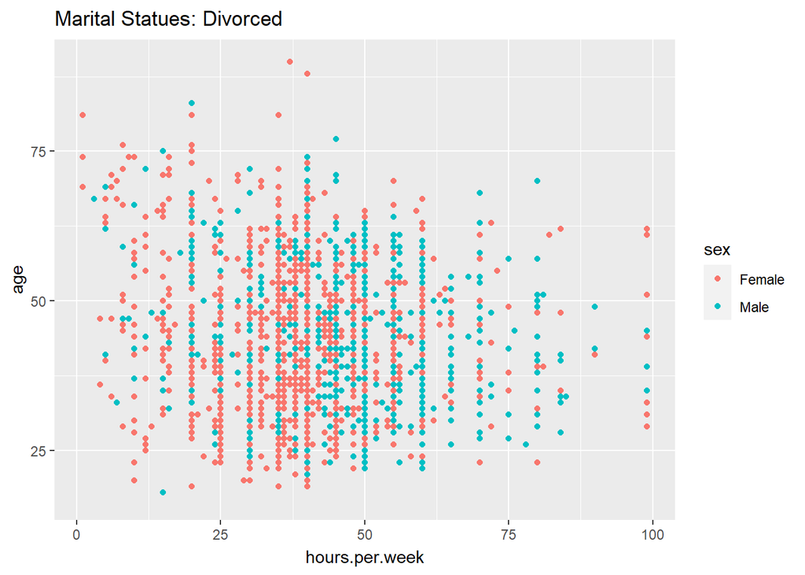

```r
df %>% ggplot(aes(x = hours.per.week,
           y = age, color=sex))+
  geom_point()+
  transition_states(marital.status)+
  labs(title = 'Marital Statues: {closest_state}')
```

2. Using the `Adult Census Income` data, make an animation using `geom_bar` and `transition_states`.

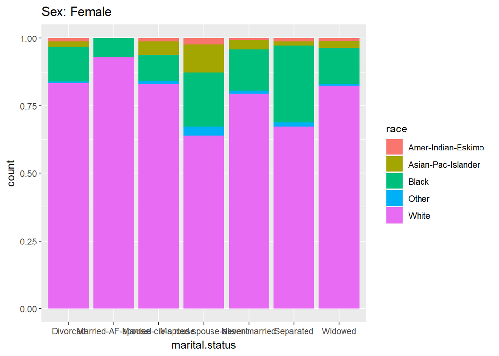

```r
df %>% ggplot(aes(x = marital.status,
                  fill=race))+
  geom_bar(position = 'fill')+
  transition_states(sex) +
  labs(title = 'Sex: {closest_state}')
```

3. Use the WHO’s dataset at [this link](https://covid19.who.int/WHO-COVID-19-global-data.csv). Make a top-10 bar race by months between countries on the number of deaths by Covid 19 in 2021.

```r
df <- read_csv('https://covid19.who.int/WHO-COVID-19-global-data.csv')

head(df)
```

```
## # A tibble: 6 × 8
##   Date_reported Country_code Country     WHO_r…¹ New_c…² Cumul…³ New_d…⁴ Cumul…⁵
##   <date>        <chr>        <chr>       <chr>     <dbl>   <dbl>   <dbl>   <dbl>
## 1 2020-01-03    AF           Afghanistan EMRO          0       0       0       0
## 2 2020-01-04    AF           Afghanistan EMRO          0       0       0       0
## 3 2020-01-05    AF           Afghanistan EMRO          0       0       0       0
## 4 2020-01-06    AF           Afghanistan EMRO          0       0       0       0
## 5 2020-01-07    AF           Afghanistan EMRO          0       0       0       0
## 6 2020-01-08    AF           Afghanistan EMRO          0       0       0       0
## # … with abbreviated variable names ¹WHO_region, ²New_cases, ³Cumulative_cases,
## #   ⁴New_deaths, ⁵Cumulative_deaths
```

```r
library(lubridate)

df$month = month(df$Date_reported)
```

```r
d1 <- df %>%
  filter(Date_reported>='2021-01-01', Date_reported<'2022-01-01') %>%
  group_by(month, Country) %>%
  summarise(sum = sum(Cumulative_deaths))
d2 <- d1 %>% group_by(month) %>% mutate(rank=rank(-sum))
d3 <- d2 %>% filter(rank <= 10)
```

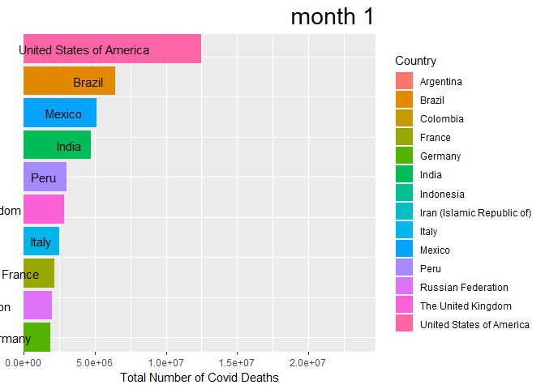

```r
a1 <- d3 %>% ggplot(aes(x=rank, y=sum, group=Country, fill=Country, label=Country)) + geom_col()+
    geom_text(aes(y = sum, label = Country), hjust = 1.4)+
    coord_flip(clip = "off", expand = FALSE) +scale_x_reverse()+
    labs(title = 'month {closest_state}', x='', y='Total Number of Covid Deaths', fill='Country')+
    theme(plot.title = element_text(hjust = 1, size = 22),
          axis.ticks.y = element_blank(),
          axis.text.y  = element_blank()) +
    transition_states(month)+
    ease_aes("cubic-in-out")
animate(a1, nframes = 400)
```

4. Make a bar race using a dataset of your own interest. You may use the dataset that we use in class (https://covidtracking.com/data/download/all-states-history.csv) but you should make a different bar racev from ones in the slides.

```r
setwd("C:/Users/student/OneDrive - Bryant University/Desktop/Math 421")
df <- read.csv('hotel_bookings.csv')
head(df)
```

```
##          hotel is_canceled lead_time arrival_date_year arrival_date_month
## 1 Resort Hotel           0       342              2015               July
## 2 Resort Hotel           0       737              2015               July
## 3 Resort Hotel           0         7              2015               July
## 4 Resort Hotel           0        13              2015               July
## 5 Resort Hotel           0        14              2015               July
## 6 Resort Hotel           0        14              2015               July
##   arrival_date_week_number arrival_date_day_of_month stays_in_weekend_nights
## 1                       27                         1                       0
## 2                       27                         1                       0
## 3                       27                         1                       0
## 4                       27                         1                       0
## 5                       27                         1                       0
## 6                       27                         1                       0
##   stays_in_week_nights adults children babies meal country market_segment
```

[output cut: 41 more lines]

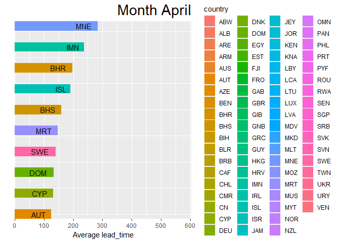

```r
d1 <- df %>% group_by(arrival_date_month, country) %>% summarise(mean = mean(lead_time))
d2 <- d1 %>% group_by(arrival_date_month) %>% mutate(rank=rank(-mean))
d3 <- d2 %>% filter(rank <= 10)
a1 <- d3 %>% ggplot(aes(x=rank, y=mean, group=country, fill=country, label=country)) + geom_col()+
    geom_text(aes(y = mean, label = country), hjust = 1.4)+
    coord_flip(clip = "off", expand = FALSE) +scale_x_reverse()+
    labs(title = 'Month {closest_state}', x='', y='Average lead_time', fill='country')+
    theme(plot.title = element_text(hjust = 1, size = 22),
          axis.ticks.y = element_blank(),
          axis.text.y  = element_blank()) +
    transition_states(arrival_date_month)+
    ease_aes("cubic-in-out")
animate(a1, nframes = 150)
```